# Barbiero_Lorenzo_rlab04

Barbiero Lorenzo

2023-05-15

```r
library(tidyverse)
library(ggpubr)
```

## Exercise 1

Recorded measurements are:

```r
meas = c(5,8,4,6,11,6,6,5,6,4)
```

### Flat and Jeffrey’s prior

```r
x <- seq(0,10,0.001)
u.post <- dgamma(x,sum(meas)+1,length(meas))
u.meanval <- sum(u.post*x*(x[2]-x[1]))
u.var <- sqrt(sum(u.post*x*x*(x[2]-x[1]))-u.meanval**2)
j.post <- dgamma(x,sum(meas)+0.5,length(meas))
j.meanval <- sum(j.post*x*(x[2]-x[1]))
j.var <- sqrt(sum(j.post*x*x*(x[2]-x[1]))-j.meanval**2)
ex1 <- data.frame(x,u.post,j.post)

quantities <- c("lower quantile","upper quantile")
flat_prior <- c(qgamma(0.025,sum(meas)+1,length(meas)),qgamma(0.975,sum(meas)+1,length(meas)))
flat_normal <- c(qnorm(0.025,u.meanval,u.var),qnorm(0.975,u.meanval,u.var))
jeff_prior <- c(qgamma(0.025,sum(meas)+0.5,length(meas)),qgamma(0.975,sum(meas)+0.5,length(meas)))
jeff_normal <- c(qnorm(0.025,j.meanval,j.var),qnorm(0.975,j.meanval,j.var))
summary <- data.frame(quantities,flat_prior,flat_normal,jeff_prior,jeff_normal)
summary
```

```
##       quantities flat_prior flat_normal jeff_prior jeff_normal
## 1 lower quantile   4.753504    4.656040   4.709748    4.612446
## 2 upper quantile   7.835705    7.743589   7.779460    7.687267
```

#### Flat Prior

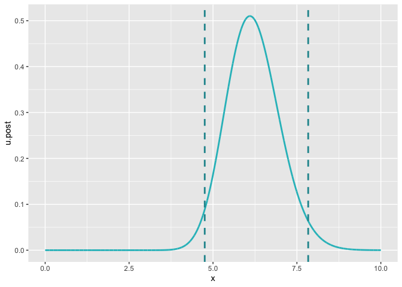

```r
(g<-ggplot(ex1)+
   geom_line(aes(x,u.post),color="#29bdc5", lwd=1)+
   geom_vline(xintercept = flat_prior[1],color="#20949c", lwd=1, linetype="dashed")+
   geom_vline(xintercept = flat_prior[2],color="#20949c", lwd=1, linetype="dashed"))
```

#### Jeffrey’s Prior

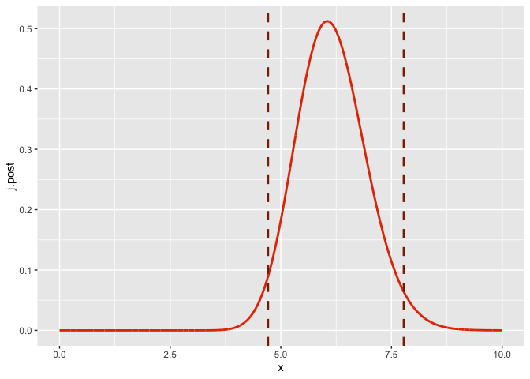

```r
(g<-ggplot(ex1)+
   geom_line(aes(x,j.post),color="#e63900", lwd=1)+
   geom_vline(xintercept = jeff_prior[1],color="#8b2900", lwd=1, linetype="dashed")+
   geom_vline(xintercept = jeff_prior[2],color="#8b2900", lwd=1, linetype="dashed"))
```

## Exercise 2

The probability distribution for the number of mis diagnoses is a Bernoulli process with p=0.15

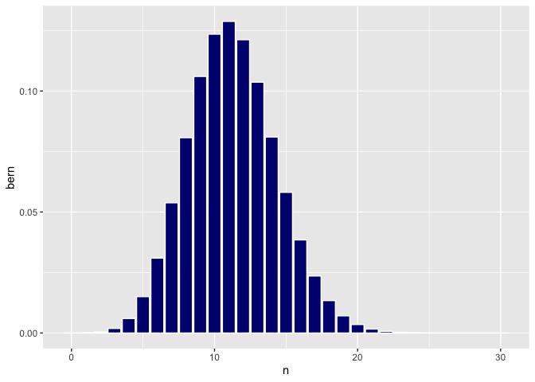

```r
n <- seq(0,30,1)
bern <- dbinom(n,75,0.15)
ex2 <- data.frame(n,bern)

(p<-ggplot(ex2)+geom_bar(aes(n,bern), stat = "identity", color="white", fill="navy"))
```

If the disease is misdiagnosed for y=6 people the frequentist estimator is

```r
pfreq <- 6/75
pfreq
```

```
## [1] 0.08
```

The Bayesian estimator is

```r
p <- seq(0,1,0.001)
M <- 0.15
V <- 0.14

alpha <- M**2*(1-M)/V-M
beta <- alpha/M

prior  <- dbeta(p,alpha,beta)
```

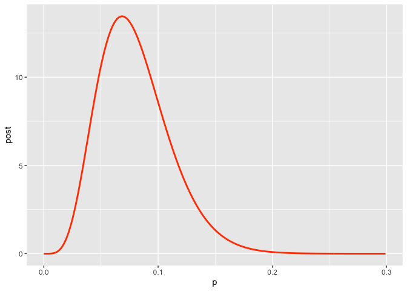

```r
post <- dbeta(p,alpha+6,beta+69)
ex22 <- data.frame(p,post)

(p<-ggplot(ex22[ex22$p<0.3,])+geom_line(aes(p,post), color="orangered", lwd=1))
```

### Hypothesis test

#### Bayesian approach

This is a case of one sided hypothesis test, in the bayesian approach we can simply refer to the previous calculations

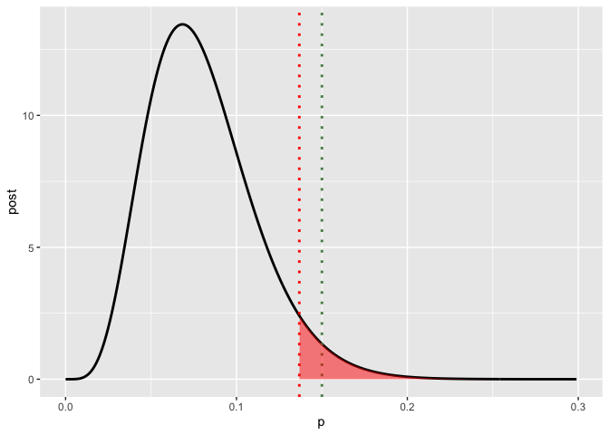

```r
(p<-ggplot(ex22[ex22$p<0.3,])+geom_line(aes(p,post),lwd=1)+
    geom_vline(xintercept=0.15, color="palegreen4",linetype="dotted", lwd=1)+
    geom_area(data=ex22[ex22$p<0.3 & ex22$p>qbeta(0.95,alpha+6,beta+69),],aes(p,post),fill="red", alpha=0.5)+
    geom_vline(xintercept=qbeta(0.95,alpha+6,beta+69), color="red", linetype="dotted", lwd=1)
    )
```

Given that the probability of having p >= 0.15 (null hypothesis) lies outside the acceptance region we reject it

#### Frequentist approach

We compute the probability that the null hypothesis is true (p >= 0.15) given the observed data, this results in computing the probability of getting at least 11 misdiagnoses

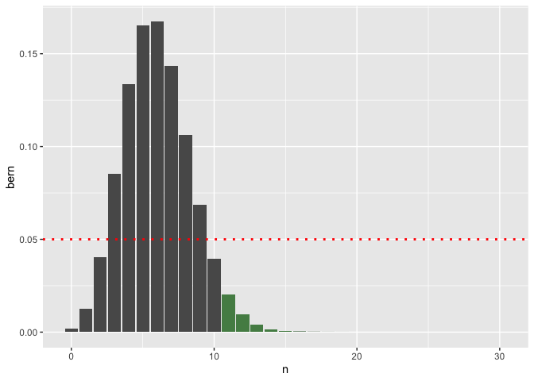

```r
bern <- dbinom(n,75,6/75)
ex2 <- data.frame(n,bern)

(p<-ggplot(ex2)+geom_bar(aes(n,bern), stat = "identity")+
    geom_bar(data=ex2[ex2$n>10,],aes(n,bern), stat = "identity", fill="palegreen4")+
    geom_hline(yintercept=0.05,color="red",linetype="dotted", lwd=1))
```

```r
pv <- sum(data=ex2[ex2$n>10,"bern"])
pv
```

```
## [1] 0.03591258
```

The null hypothesis is, thus, rejected

## Lighthouse Problem

Generate data

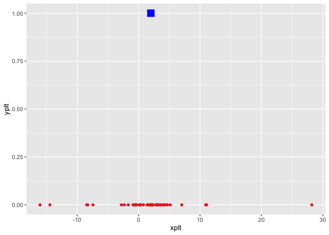

```r
set.seed(1234)
lhdata <- function(N,a,b) {
  x <- b*tan(runif(N,-pi,pi))+a
  return(x)
}

a.true <- 2
b.true <- 1
dat <- lhdata(50,a.true,b.true)

xplt <- c(a.true,dat)
yplt <- c(b.true,rep(0,length(dat)))
plt <- data.frame(xplt,yplt)

(g<-ggplot(plt)+geom_point(aes(xplt,yplt), color="firebrick2")+geom_point(data=plt[1,],aes(xplt,yplt),color="blue", size=5, shape=15))
```

## Exercise 3

The likelihood is the same as the one calculated in class but needs to be evaluated on a grid of values for a and b.

```r
lhood <- function(x,a,b){
  l <- 0
  for (i in x) {
    l <- l + log(b) - log(b**2 + (i-a)**2)
  }
  return(l)
}
```

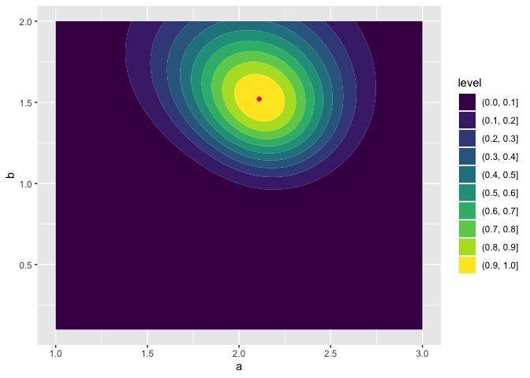

```r
A <- seq(1,3,0.01)
B <- seq(0.1,2,0.01)

DF <- rep(0,length(A)*length(B))

res <- data.frame(DF,DF,DF)
colnames(res) <- c("a","b","lhood")

k <- 1
for (i in A) {
  for (j in B) {
    res[k,] <- c(i,j,lhood(dat,i,j))
    k <- k+1
  }
}
res[,"lhood"] <- res[,"lhood"]-max(res[,"lhood"])
res[,"lhood"] <- exp(res[,"lhood"])
maxlh <- res[res$lhood==max(res[,"lhood"]),]

(p <- ggplot(res)+stat_contour_filled(aes(x=a,y=b,z=lhood))+
    geom_point(data=maxlh,aes(a,b),color="red"))
```

Marginalization

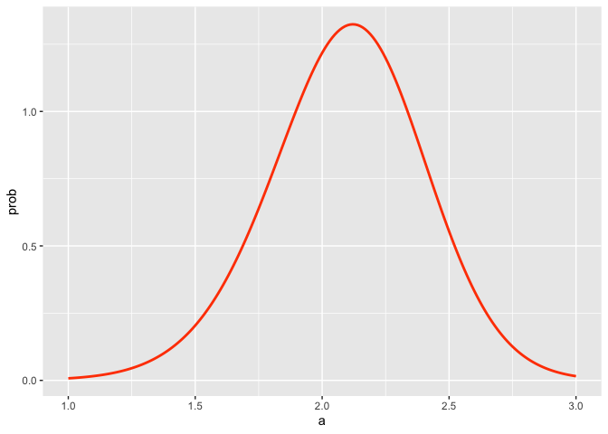

```r
marg_a <- data.frame(A,rep(0,length(A)))
colnames(marg_a) <- c("a","prob")

for (i in marg_a[,"a"]) {
  bvalues <- res[res$a==i,"lhood"]
  marg_a[marg_a$a==i,"prob"] <- sum(bvalues)
}
marg_a[,"prob"] <- marg_a[,"prob"]/((A[2]-A[1])*sum(marg_a[,"prob"]))
(p<-ggplot(marg_a)+geom_line(aes(a,prob),color="orangered",lwd=1))
```

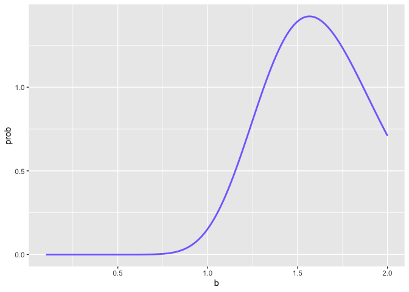

```r
marg_b <- data.frame(B,rep(0,length(B)))
colnames(marg_b) <- c("b","prob")

for (i in marg_b[,"b"]) {
  bvalues <- res[res$b==i,"lhood"]
  marg_b[marg_b$b==i,"prob"] <- sum(bvalues)
}
marg_b[,"prob"] <- marg_b[,"prob"]/((B[2]-B[1])*sum(marg_b[,"prob"]))
(p<-ggplot(marg_b)+geom_line(aes(b,prob),color="lightslateblue",lwd=1))
```

## Exercise 4

The general framework will be similar to the previous exercise

```r
sgn <- function(x, a, b, x0, w, t) {return(t * (a*exp(-(x-x0)**2/(2*w**2)) + b))}

log.post <- function(d, x, a, b, x0, w, t) {
  sum(dpois(d, lambda=sgn(x, a, b, x0, w, t), log=TRUE))
}
```

Generate signal, data and plot function

```r
x0 <- 0
w <-1
A.true <- 2
B.true <- 1
Delta.t <- 5
```

```r
x <- seq(from=-7*w, to=7*w, by=0.01*w) #signal
signal <- sgn(x,A.true,B.true,0,w,Delta.t)

resolution <- 0.5 #data
xdat <- seq(from=-7*w, to=7*w, by=resolution*w)
meas <- sgn(xdat,A.true,B.true,0,w,Delta.t)
data <- rpois(length(meas), meas)

plf <- function(x,signal,xdat,data) {
  sn <- data.frame(x,signal)
  ms <- data.frame(xdat,data)
  g <- ggplot() + geom_bar(aes(xdat,data), stat = "identity", fill="violetred1",color="white") + geom_line(data=sn, aes(x,signal), color="dodgerblue2", lwd=1.5)
  return(g)
}
```

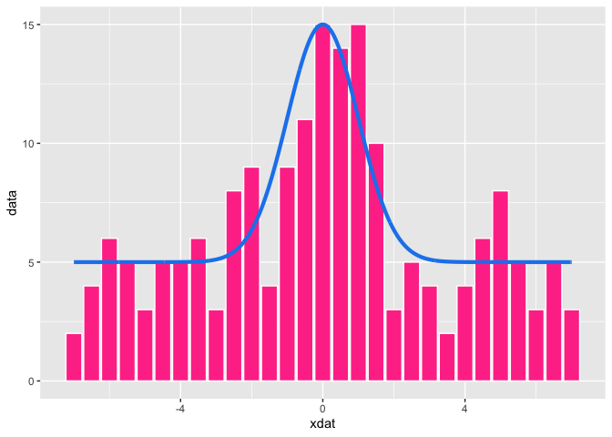

```r
(plf(x,signal,xdat,data))
```

Compute unnnormalized likelihood

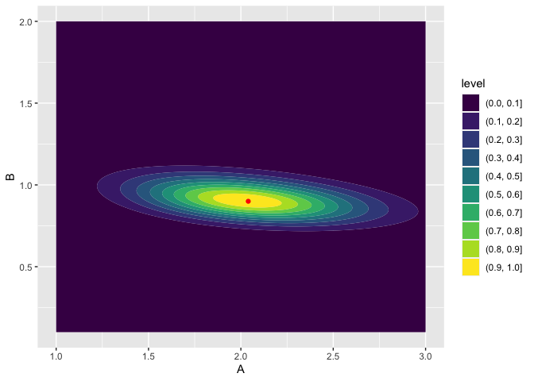

```r
A <- seq(1,3,0.01)
B <- seq(0.1,2,0.01)

DF <- rep(0,length(A)*length(B))

res <- data.frame(DF,DF,DF)
colnames(res) <- c("A","B","lhood")

k <- 1
for (i in A) {
  for (j in B) {
    res[k,] <- c(i,j,log.post(data,xdat,i,j,x0,w,Delta.t))
    k <- k+1
  }
}
res[,"lhood"] <- res[,"lhood"]-max(res[,"lhood"])
res[,"lhood"] <-  exp(res[,"lhood"])
maxlh <- res[res$lhood==max(res[,"lhood"]),]
(p <- ggplot()+stat_contour_filled(data=res,aes(x=A,y=B,z=lhood))+geom_point(data=maxlh,aes(A,B),color="red"))
```

Marginalization

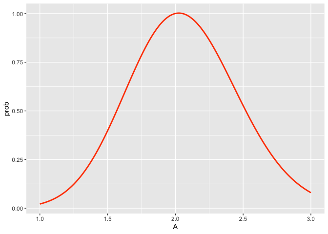

```r
marg_a <- data.frame(A,rep(0,length(A)))
colnames(marg_a) <- c("A","prob")

for (i in marg_a[,"A"]) {
  bvalues <- res[res$A==i,"lhood"]
  marg_a[marg_a$A==i,"prob"] <- sum(bvalues)
}
marg_a[,"prob"] <- marg_a[,"prob"]/((A[2]-A[1])*sum(marg_a[,"prob"]))
(p<-ggplot(marg_a)+geom_line(aes(A,prob),color="orangered",lwd=1))
```

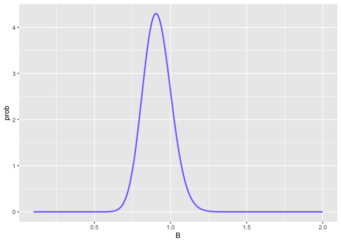

```r
marg_b <- data.frame(B,rep(0,length(B)))
colnames(marg_b) <- c("B","prob")

for (i in marg_b[,"B"]) {
  bvalues <- res[res$B==i,"lhood"]
  marg_b[marg_b$B==i,"prob"] <- sum(bvalues)
}
marg_b[,"prob"] <- marg_b[,"prob"]/((B[2]-B[1])*sum(marg_b[,"prob"]))
(p<-ggplot(marg_b)+geom_line(aes(B,prob),color="lightslateblue",lwd=1))
```

#### Changing the resolution

For the next steps I’m gonna recap everything into a single function and provide the graphic results

```r
twoparanalysis <- function(a, b, x0, w, t, resl) {
  x <- seq(from=-7*w, to=7*w, by=0.01*w) #signal
  signal <- sgn(x,A.true,B.true,0,w,Delta.t)

  resolution <- resl #data
  xdat <- seq(from=-7*w, to=7*w, by=resolution*w)
  meas <- sgn(xdat,A.true,B.true,0,w,Delta.t)
  data <- rpois(length(meas), meas)

  plf <- function(x,signal,xdat,data) {
    sn <- data.frame(x,signal)
    ms <- data.frame(xdat,data)
    g <- ggplot() + geom_bar(aes(xdat,data), stat = "identity", fill="violetred1",color="white") +   geom_line(data=sn, aes(x,signal), color="dodgerblue2", lwd=1.5)
  return(g)
  }
  p1 <- plf(x,signal,xdat,data)


  A <- seq(a-1,a+1,0.01)
  B <- seq(b-1+0.1,b+1,0.01)

  DF <- rep(0,length(A)*length(B))
  res <- data.frame(DF,DF,DF)
  colnames(res) <- c("A","B","lhood")

  k <- 1
  for (i in A) {
    for (j in B) {
      res[k,] <- c(i,j,log.post(data,xdat,i,j,x0,w,Delta.t))
      k <- k+1
    }
  }
  res[,"lhood"] <- res[,"lhood"]-max(res[,"lhood"])
  res[,"lhood"] <-  exp(res[,"lhood"])
  maxlh <- res[res$lhood==max(res[,"lhood"]),]
  p2 <- ggplot()+stat_contour_filled(data=res,aes(x=A,y=B,z=lhood))+geom_point(data=maxlh,aes(A,B),color="red")+theme(legend.position = "none")


  marg_a <- data.frame(A,rep(0,length(A)))
  colnames(marg_a) <- c("A","prob")

  for (i in marg_a[,"A"]) {
    bvalues <- res[res$A==i,"lhood"]
    marg_a[marg_a$A==i,"prob"] <- sum(bvalues)
  }
  marg_a[,"prob"] <- marg_a[,"prob"]/((A[2]-A[1])*sum(marg_a[,"prob"]))
  p3<-ggplot(marg_a)+geom_line(aes(A,prob),color="orangered",lwd=1)


  marg_b <- data.frame(B,rep(0,length(B)))
  colnames(marg_a) <- c("B","prob")

  for (i in marg_b[,"B"]) {
    bvalues <- res[res$B==i,"lhood"]
    marg_b[marg_b$B==i,"prob"] <- sum(bvalues)
  }
  marg_b[,"prob"] <- marg_b[,"prob"]/((B[2]-B[1])*sum(marg_b[,"prob"]))
  p4<-ggplot(marg_b)+geom_line(aes(B,prob),color="lightslateblue",lwd=1)

plot <- ggarrange(p1,p2,p3,p4, nrow=2, ncol=2, heights = c(1,1))
return(plot)
}
```

#### Changing the resolution

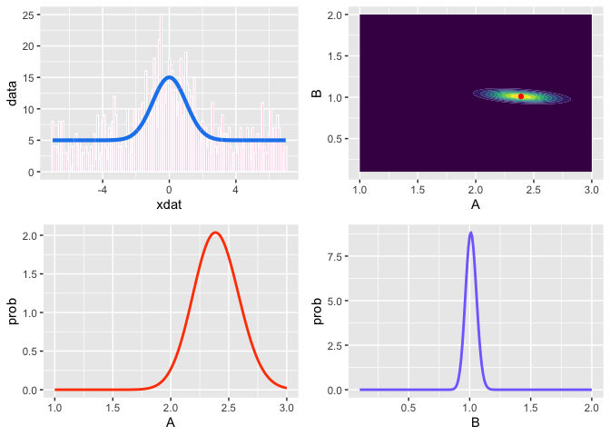

```r
x0 <- 0
w <-1
A.true <- 2
B.true <- 1
Delta.t <- 5
resolution <- 0.1

(twoparanalysis(A.true,B.true,x0,w,Delta.t,resolution))
```

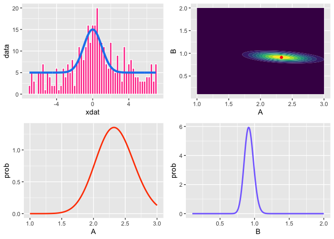

```r
x0 <- 0
w <-1
A.true <- 2
B.true <- 1
Delta.t <- 5
resolution <- 0.25

(twoparanalysis(A.true,B.true,x0,w,Delta.t,resolution))
```

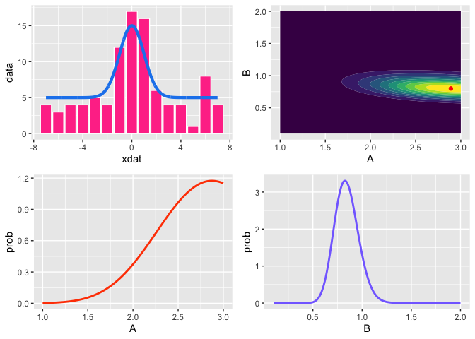

```r
x0 <- 0
w <-1
A.true <- 2
B.true <- 1
Delta.t <- 5
resolution <- 1

(twoparanalysis(A.true,B.true,x0,w,Delta.t,resolution))
```

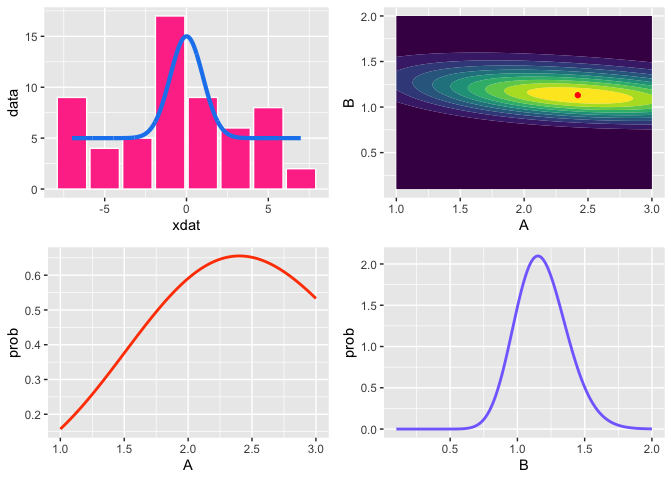

```r
x0 <- 0
w <-1
A.true <- 2
B.true <- 1
Delta.t <- 5
resolution <- 2

(twoparanalysis(A.true,B.true,x0,w,Delta.t,resolution))
```

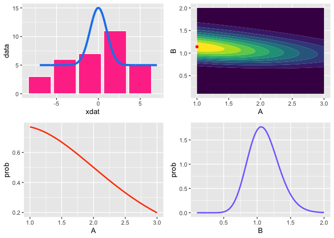

```r
x0 <- 0
w <-1
A.true <- 2
B.true <- 1
Delta.t <- 5
resolution <- 3

(twoparanalysis(A.true,B.true,x0,w,Delta.t,resolution))
```

As expected increasing the resolution of the detector drammaticaly improves performance